# Engagement Survey Technical Report

Eagle I.O

Most recently updated 2021-07-06

# Home

# Introduction

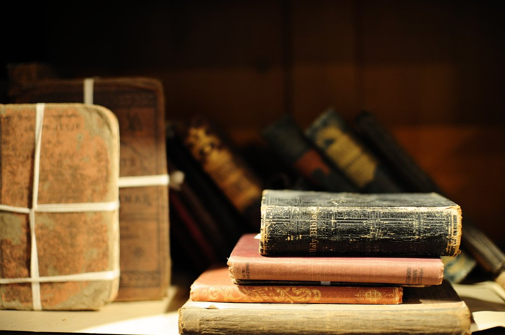

## Definitions of Engagement

The roots of employee (aka work; e.g., W. Schaufeli & Bakker, 2010) engagement research likely started with theoretical expansions of forms of employee participation (see, for example, Ferris & Hellier, 1984) and job involvement (e.g., Elloy et al., 1991). This exploration extended into broader considerations of attitudes and emotions (Staw et al., 1994) and were informed by further exploration of the dimensionality of constructs such as organizational commitment (Meyer & Allen, 1991). The 1990’s saw focused development and refinement (for example, a dissertation; Leone (1995) or actual semantic reference; Kahn (1990)). Staw et al. (1994) investigated the relationships between *positive emotions* and favourable work outcomes, and although they do not use the word, “engagement,” their distinction between felt and expressed emotion was likely a stimulating influence upon the burgeoning interest in the engagement construct. Gallup is also widely acknowledged as an early pioneer in the measurement of the construct (see, for example, Coffman & Harter, 1999).

Kahn (1990) described engaged employees as being physically involved, cognitively vigilant, and emotionally connected. Although occasionally referred to as residing on the opposing pole to *burnout* (Christina Maslach & Leiter, 2008), these two constructs are currently most commonly conceptualized as being distinct (Timms et al., 2012), although not universally (Cole et al., 2012; Taris et al., 2017).

- Engagement/Burnout: Burnout is defined as a psychological syndrome characterized by exhaustion, cynicism, and inefficacy, which is experienced in response to chronic job stressors. Engagement is understood to be the direct opposite of burnout and exist on a continuum—with engagement on one end and burnout on the other. Exhaustion (low energy), cynicism (low involvement), and inefficacy (low efficacy) are characteristic of burnout; whereas, high energy, high involvement, and high efficacy are characteristic of engagement C. Maslach & Leiter (1997) (Maslach and Leiter, 1997) (Leiter & Maslach, 2004).
- Work engagement: Work engagement refers to a positive, fulfilling, work-related state of mind that is characterized by vigor, dedication, and absorption. Vigor is characterized by high levels of energy and mental resilience while working. Dedication refers to being strongly involved in one’s work and experiencing a sense of significance, enthusiasm, inspiration, pride, and challenge. Absorption is characterized by being fully concentrated and happily engrossed in one’s work, whereby time passes quickly and one has difficulties with detaching oneself from work (Wilmar B. Schaufeli et al., 2002) - The Utrecht Work Engagement Scale (UWES), a self-report questionnaire first developed by Schaufeli and Bakker (2003) (W. B. Schaufeli & Bakker, 2003) includes the three aspects of work engagement: vigor, dedication, and absorption. - we have to make note of how we are different from this!
- Employee engagement: Employee engagement refers to the ‘‘individual’s involvement and satisfaction as well as enthusiasm for work’’ (Harter et al., 2002) Work engagement is the mental state where employees…
- …feel full with physical energy (**Vigor**)
- …are enthusiastic about the content of their work and the things they do (**Dedication**)
- …are so immersed in their work activities that time seems to fly (**Absorption**)

The tripartite substantive model of employee engagement is also partially informed by the definitions provided with the Utrecht Work Engagement Scale (Wilmar B. Schaufeli & Bakker, 2003).

# Instrument creation

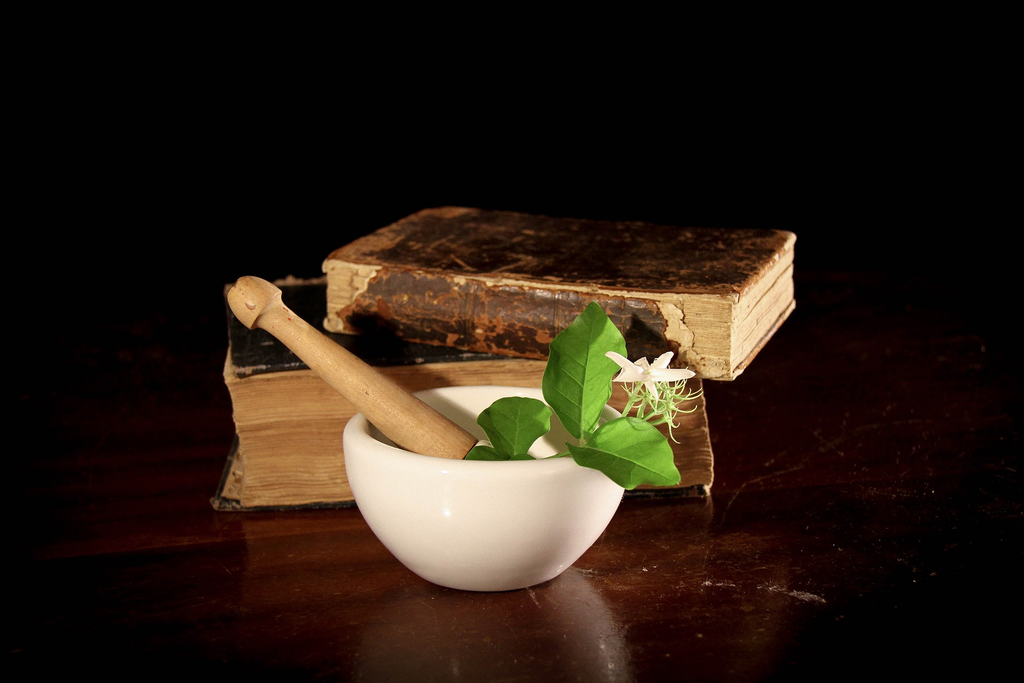

## Intended Structure

At some point we decided to attempt an *a priori* bi-factor structure, whereby each of the substantive dimensions (Dedication, Vigor, and Absorption)[^1] could further be deconstructed into the attitudinal elements of Cognition, Affect, and Behavior (see, for example, Eagly & Chaiken, 1993; Rosenberg, 1960).

The most relevant acknowledgement of this potential confound was made by Wilmar B. Schaufeli et al. (2002) (pp. 74-75):

> Hence, engagement is defined as a positive, fulfilling, work-related state of mind that is characterized by vigor, dedication, and absorption. Rather than a momentary and specific state, engagement refers to a more persistent and pervasive affective cognitive state that is not focused on any particular object, event, individual, or behavior. *Vigor* is characterized by high levels of energy and mental resilience while working, the willingness to invest effort in one’s work, and persistence even in the face of difficulties. *Dedication* is characterized by a sense of significance, enthusiasm, inspiration, pride, and challenge. Instead of involvement we prefer to use the term dedication. Although, involvement – like dedication (see above) – is usually defined in terms of psychological identification with one’s work or one’s job (Kanungo, 1982; Lawler and Hall, 1970), whereby the latter goes one step beyond, both quantitatively as well as qualitatively. In a qualitative sense, dedication refers to a particularly strong involvement that goes one step further than the usual level of identification. In a qualitative sense, dedication has a wider scope by not only referring to a particular cognitive or belief state but including the affective dimension as well. The final dimension of engagement, *absorption*, is characterized by being fully concentrated and deeply engrossed in one’s work, whereby time passes quickly and one has difficulties with detaching oneself from work.

The survey is intentionally complex in terms of item and scale associations. There are three substantive engagement dimensions as well as three attitudinal dimensions, and item cross-loadings are intended to fully exhaust the 3 x 3 conditions (e.g., each item loads on one substantive and one attitudinal dimension):

| Substantive | Attitudinal |
| --- | --- |
| Dedication | Affective |
| Absorption | Behavioral |
| Vigor | Cognitive |

The feedback report uses the terms, “feel,” “do,” and “think” instead of the Psychological literature-based affect, behavior, and cognition.

## Item generation

After content validation but prior to settling on 4 candidate items per 3x3 condition, there was a dearth of items within some of the Affective, Cognitive, or Behavioral item groupings. We generated additional candidates at this point and have these items [located here](https://docs.google.com/document/d/1whB4Ve4aDDl3bxx3dIlloouTDy1ScCcxrT3gK6s9DyU/edit?usp=sharing) (Montclair State University e-mail needed to access). It was from this larger list of (reduced) candidate items that the 36 pilot candidates were identified (and in some cases modified, edited, or otherwise further crafted)

## Content Validation

> INSTRUCTIONS: Place an “X” in the column that you feel is the best fit for each item (only one “X” per row please)

The substantive scale definitions provided for ratings were:

- *Absorption*: Being fully immersed in one’s work, where time passes quickly and one has difficulty detaching from work tasks
- *Vigor*: Experiencing persistent levels of energy, effort, and enthusiasm while working
- *Dedication*: Experiencing pride and challenge in ones work, as well as strong feelings of support from and loyalty toward the organization

The attitudinal scale definitions were:

- *Cognitive*: Pertaining to thoughts or general mental processes (for example what someone thinks)
- *Affective*: Pertaining to feelings or emotions (for example, how someone feels)
- *Behavioral*: Pertaining to acts or actions (for example, what someone does)

The goal was to identify item(s) that were equally and heavily implicated with one substantive and one attitudinal scale.

# Procedure

## Pilot

### Sampling strategy (pilot)

#### Pilot analyses

## Demographic Information

# Analyses

## Pilot analyses

### Classical test theory

#### Internal consistency estimates

### Confirmatory factor analyses

#### Multigroup analyses

#### Bifactor analyses

### Summary

## Construct and Criterion-related Validation

# Future plans

## Things to do

## Research projects

# Author bios

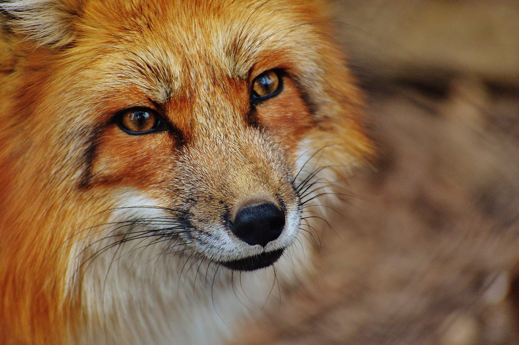

Casey Osorio-Duffoo received his M.A. in Industrial and Organizational Psychology from Montclair State University. He enjoys stealing chicken eggs from hen coops and outwitting crows. [**NOTE**. Currently being held against own will in avian rehab]

Renata Garcia Prieto Palacios Roji is pursuing her Ph.D. in Industrial and Organizational Psychology at Montclair State University. She enjoys allfallfa, the smellll of llavender, and glleefulllly prancing through dew-filllled meadows.

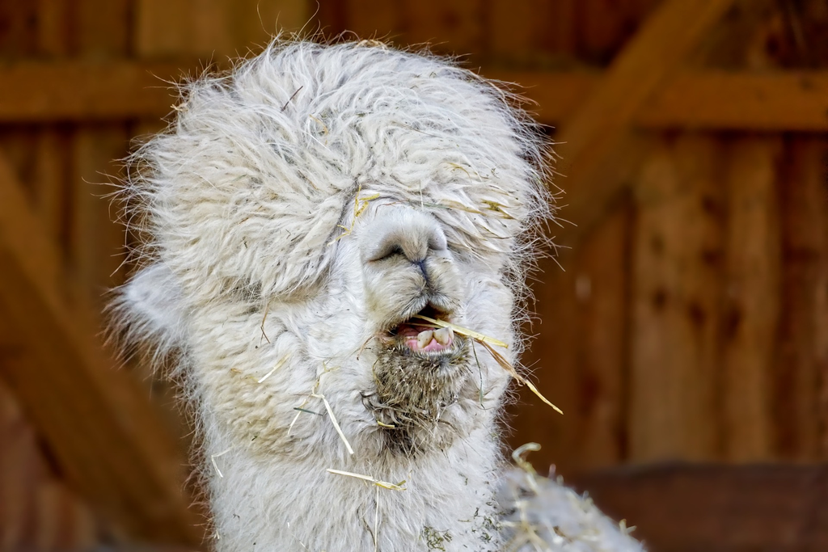

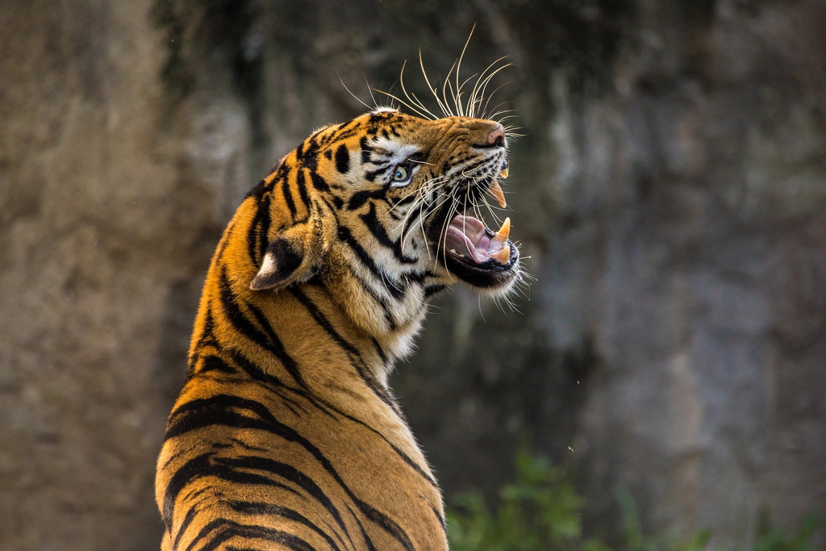

John Kulas received his Ph.D. in Industrial and Organizational Psychology from Northern Illinois University. He feels ashamed of his previous obsession with the evisceration of the mancub Mowgli, and is currently easing into a vegan lifestyle, slowly weaning himself from a diet consisting primarily of foxes and llamas.

# References

## Spring 2019

## Spring 2020

### February 4, 2020

### February 24, 2020

### Structural considerations

## Summer 2020

## Inter-Item correlations

## Scale-level correlations

### Substantive scales

### Attitudinal scales

## Substantive scale (marginal level)

## Substantive scale (cell level)

## Frequency distributions by dimension

## Tables of qualitative indices

Coffman, C., & Harter, J. (1999). A hard look at soft numbers. *Position Paper, Gallup Organization*.

Cole, M. S., Walter, F., Bedeian, A. G., & O’Boyle, E. H. (2012). Job burnout and employee engagement: A meta-analytic examination of construct proliferation. *Journal of Management*, *38*(5), 1550–1581.

Eagly, A. H., & Chaiken, S. (1993). *The psychology of attitudes*. Harcourt Brace Jovanovich College Publishers.

Elloy, D. F., Everett, J. E., & Flynn, W. R. (1991). An examination of the correlates of job involvement. *Group & Organization Studies*, *16*(2), 160–177. https://doi.org/10.1177/105960119101600204

Ferris, R., & Hellier, P. (1984). Added value productivity schemes and employee participation. *Asia Pacific Journal of Human Resources*, *22*(4), 35–44. https://doi.org/10.1177/103841118402200406

Harter, J. K., Schmidt, F., & Hayes, T. (2002). Business-unit-level relationship between employee satisfaction, employee engagement, and business outcomes: A meta-analysis. *The Journal of Applied Psychology*. https://doi.org/10.1037/0021-9010.87.2.268

Kahn, W. A. (1990). Psychological conditions of personal engagement and disengagement at work. *Academy of Management Journal*, *33*(4), 692–724.

Kaiser, F. G., & Wilson, M. (2019). The Campbell Paradigm as a Behavior-Predictive Reinterpretation of the Classical Tripartite Model of Attitudes. *European Psychologist*, *24*(4), 359–374. https://doi.org/10.1027/1016-9040/a000364

Leiter, M., & Maslach, C. (2004). Areas of worklife: A structured approach to organizational predictors of job burnout. In *Research in occupational stress and well-being* (Vol. 3, pp. 91–134). https://doi.org/10.1016/S1479-3555(03)03003-8

Leone, D. R. (1995). *The relation of work climate, higher order need satisfaction, need salience, and causality orientations to work engagement, psychological adjustment, and job satisfaction* [PhD thesis]. ProQuest Information & Learning.

Maslach, C., & Leiter, M. (1997). What causes burnout. *Maslach C, Leiter MP. The Truth About Burnout: How Organizations Cause Personal Stress and What to Do about It. San Francisco, CA: Josey-Bass Publishers*, 38–60.

Maslach, Christina, & Leiter, M. P. (2008). Early predictors of job burnout and engagement. *Journal of Applied Psychology*, *93*(3), 498–512.

Meyer, J. P., & Allen, N. J. (1991). A three-component conceptualization of organizational commitment. *Human Resource Management Review*, *1*(1), 61–89.

Pachankis, J. (2007). The Psychological Implications of Concealing a Stigma: A Cognitive–Affective–Behavioral Model. *Psychological Bulletin*, *133*, 328–345. https://doi.org/10.1037/0033-2909.133.2.328

Rosenberg, M. J. (1960). Cognitive, affective, and behavioral components of attitudes. In *Attitude organization and change*.

Schaufeli, Wilmar B., & Bakker, A. B. (2003). Utrecht work engagement scale. *Occupational Health Psychology Unit Utrecht University*, *1*.

Schaufeli, W. B., & Bakker, A. B. (2003). UWES–utrecht work engagement scale: Test manual. *Unpublished Manuscript: Department of Psychology, Utrecht University*, *8*.

Schaufeli, Wilmar B., Salanova, M., González-Romá, V., & Bakker, A. B. (2002). The measurement of engagement and burnout: A two sample confirmatory factor analytic approach. *Journal of Happiness Studies*, *3*(1), 71–92.

Schaufeli, W., & Bakker, A. (2010). The conceptualization and measurement of work engagement. In W. Schaufeli, A. Bakker, & M. Leiter (Eds.), *Work engagement: A handbook of essential theory and research* (pp. 10–24). Psychology Press.

Staw, B. M., Sutton, R. I., & Pelled, L. H. (1994). Employee positive emotion and favorable outcomes at the workplace. *Organization Science*, *5*(1), 51–71.

Taris, T. W., Ybema, J. F., & Beek, I. van. (2017). Burnout and engagement: Identical twins or just close relatives? *Burnout Research*, *5*, 3–11.

Timms, C., Brough, P., & Graham, D. (2012). Burnt-out but engaged: The co-existence of psychological burnout and engagement. *Journal of Educational Administration*, *50*(3), 327–345.

[^1]: We also discovered at this point that some contagious agent has infiltrated the minds of people working on this project, such that the word, “absorption” confounds our spelling abilities, and roughly 50% of the time ends up being spelled (misspelled?), “absorbtion”…
[^2]: We did, however, find some criticisms of the tripartite model of attitudes as originally specified by Rosenberg (1960), although there has also been a recent attempt to reintroduce and improve upon the original model (Kaiser & Wilson, 2019) as well as repurposing of the framework as a *process* [e.g., thoughts and feelings leading to behavior; Pachankis (2007)].